# Predict the President (Neural Networks)

Author

Kenneth Ssekimpi

# Abstract

**Keywords**: bag-of-words, feed-forward, neural networks, random forest, classification, sona, gradient-boosted trees, south africa

# Introduction

The State of the Nation Address (SONA) delivered annually by the President of South Africa stands as a critical event in the nation’s political landscape. The address, traditionally presented to a joint sitting of Parliament, serves as a platform for the President to provide an extensive account of the nation’s status, articulate government policies and priorities, and outline a vision for the future. The speeches delivered during SONA ceremonies offer a vital archive of insights into the governance of South Africa, spanning from its triumphant post-apartheid era in 1994 to the present day.

Of particular significance is the observation that in the years coinciding with national elections, the SOAN unfolds twice: once before the election and again after it. This unique occurrence reflects the dynamism of South African politics and governance, encapsulating the nation’s evolving concerns and priorities.

Within this intricate and nuanced context, our research endeavours to understake a multifaceted exploration. We have been granted access to an extensive compendium of SONA speeches, sourced from the official government repository, covering the years 1994 to 2023. Our overarching objective is to construct a series of predictive machine learning models, each designed to analyze a given sentence of text and, through their learned patterns, attribute it to the respective President who delivered it.

This academic pursuit embodies an investigation into the trajectory of leadership and governance in South Africa. The predictive models decode the unique traits and qualities of each President, providing insights into public discourse as well as offering a lens through which to observe the South African government’s priorities, challenges, and plans over time.

# Literature Review

# Data and Methodology

The full text of SONA speeches, from 1994 to 2023, was collected from the official South African Governement website. Data preprocessing is an essential phase in text analysis, aimed at transforming the raw text data into a structured format suitable for in-depth analysis of the speeches. For this we chose the 'tidytext' package found in R programming language which provided a versatile platform for text analysis.

This research paper outlines the systematic approach taken to explore different data representations, predictive methodologies, and training/testing techniques. The primary objective is to investigate and determine the most effective strategies for the classification of presidential speeches using machine learning models.

## Data Representation

### *Selection of Top Words*

Another critical consideration was the selection of the most relevant words for our predictive model. We experimented with different word count thresholds, such as the top 100 and top 200 words. This allowed us to assess how the choice of the number of words would impact the model’s performance.

## Training and Testing Strategies

### *Training and Testing Split*

The dataset was divided into separate training and testing sets to assess the model’s generalization ability. The split ratio was 80% for training and 20% for testing, following best practices for machine learning model evaluation.

## Experimental Results

### *Performance Metrics*

```
# A tibble: 8,518 × 204
   sentID President deputy justice madame national president provincial security
    <int> <chr>      <int>   <int>  <int>    <int>     <int>      <int>    <int>
 1      1 Mandela        3       1      1        1         2          1        1
 2      2 Mandela        0       0      0        0         0          0        0
 3      3 Mandela        0       0      0        0         0          0        0
 4      5 Mandela        0       0      0        0         0          0        0
 5      6 Mandela        0       0      0        0         0          0        0
 6      7 Mandela        0       0      0        0         0          0        0
 7      8 Mandela        0       0      0        0         0          0        0
 8      9 Mandela        0       0      0        0         0          0        0
 9     10 Mandela        0       0      0        0         0          0        0
10     11 Mandela        0       0      0        0         0          0        0
# ℹ 8,508 more rows
# ℹ 195 more variables: speaker <int>, africans <int>, children <int>,
#   citizens <int>, nation <int>, south <int>, time <int>, world <int>,
#   youth <int>, african <int>, human <int>, hope <int>, life <int>,
#   country <int>, commitment <int>, poor <int>, africa <int>, law <int>,
#   police <int>, achieve <int>, government <int>, people <int>, role <int>,
#   society <int>, freedom <int>, create <int>, institutions <int>, …
```

# Results

[output not shown]

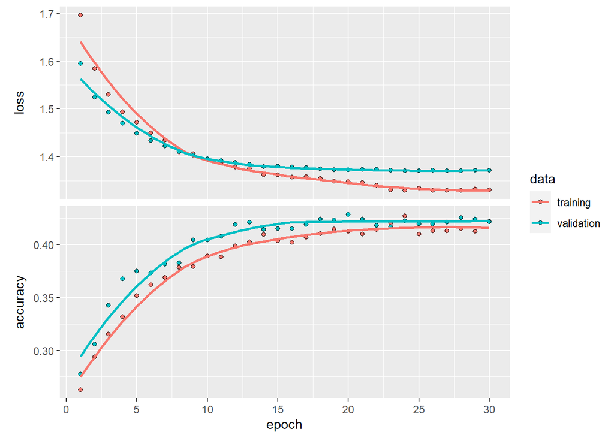

```
14/14 - 0s - loss: 1.3074 - accuracy: 0.4396 - 45ms/epoch - 3ms/step
```

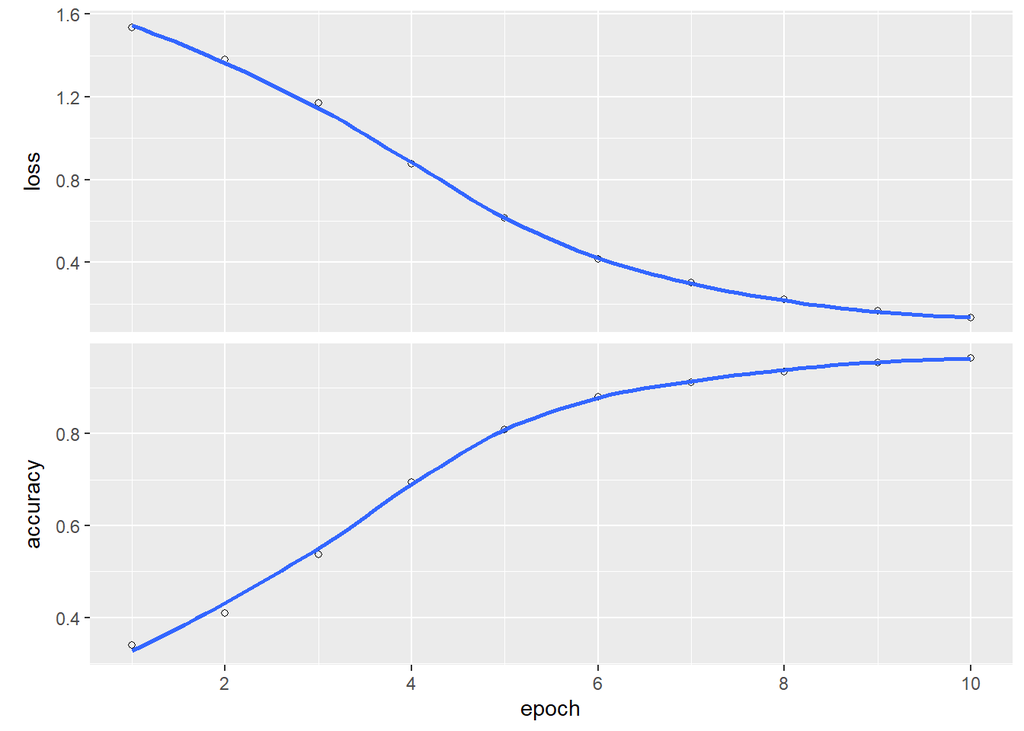

```
54/54 - 0s - loss: 1.6815 - accuracy: 0.4909 - 236ms/epoch - 4ms/step
```

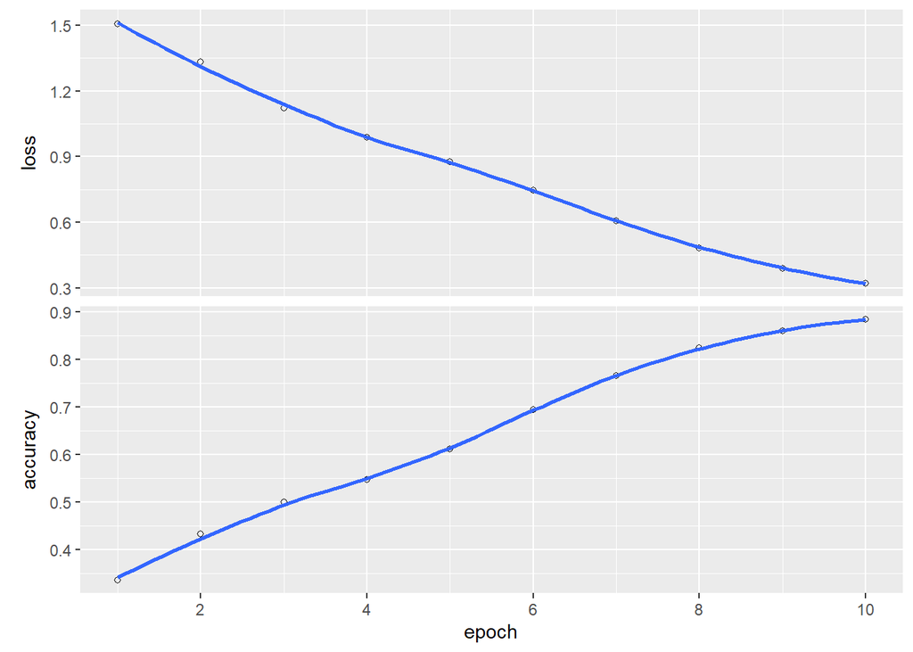

```
54/54 - 0s - loss: 1.7818 - accuracy: 0.5061 - 245ms/epoch - 5ms/step
```

```
     loss  accuracy
1.7818280 0.5061439
```

## Conclusions and Recommendations

# Discussion & Conclusion

## Implications

The choice of data representation, predictive approach, and training/testing methodology is crucial in determining the success of a machine learning task. Our research underscores the importance of systematically exploring these aspects to optimize model performance.

## Future Work

Future research can delve deeper into fine-tuning hyperparameters and exploring more advanced natural language processing techniques, such as word embeddings. Additionally, investigating the impact of feature engineering and ensemble methods could lead to further improvements in predictive accuracy.